# Coding Assignment 2

Sergio Becerra  
NetID: Sbecerr2  
UID 6693 **5933**

## Part 1

Loading the data below. Adapted from code provided.

```python
import numpy as np
import matplotlib.pyplot as plt
from sklearn import linear_model as lm
import csv
import glmnet
```

The csv file is read in and split into X and y:

```python
path = '/Users/sergiobecerra/UIUC/CS598-StatisticalLearning/Assignments/Coding2_myData.csv'
with open(path, 'r') as f:
    reader = csv.reader(f, delimiter=',')
    headers = next(reader)
    data = np.array(list(reader)).astype(float)
print(headers)
print(data.shape)
X=data[:,0:13]
y=data[:,13]
```

```
['crim', 'zn', 'indus', 'chas', 'nox', 'rm', 'age', 'dis', 'rad', 'tax', 'ptratio', 'black', 'lstat', 'Y']
(506, 14)
```

```python
print(X.shape, len(y))
```

```
(506, 13) 506
```

```python
var_names
```

```
array(['CRIM', 'ZN', 'INDUS', 'CHAS', 'NOX', 'RM', 'AGE', 'DIS', 'RAD',
       'TAX', 'PTRATIO', 'B', 'LSTAT'], dtype='<U7')
```

The mean and std of the 13 columns of X used to scale and create Xs. Y is centered.

```python
def MyLasso(X, y, lam_seq, maxit = 500):

    # X: n-by-p design matrix without the intercept
    # y: n-by-1 response vector
    # lam_seq: sequence of lambda values
    # maxit: number of updates for each lambda

    # Center/Scale X
    # Center y

    n, p = X.shape
    nlam = len(lam_seq)

    # Record the corresponding means and scales
    y_mean=np.mean(y)
    X_mean=np.mean(X,axis=0)
    X_std=np.std(X,axis=0)
    Xs=X-X_mean
    Xs=Xs/X_std

    y=y-y_mean

    # Initilize coef vector b and residual vector r
    b = np.zeros(p)
    r = y
    r=r.reshape(-1,1)
    B = np.zeros((nlam, p + 1))
    # Triple nested loop
    for m in range(nlam):
        lam = 2 * n * lam_seq[m]
        for step in range(maxit):
            for j in range(p):
                Xs_j = Xs[:, j].reshape(-1,1)
                r = r + Xs_j * b[j]
                b[j] = one_var_lasso(r, Xs_j, lam)
                r = r - Xs_j * b[j]
        B[m, 1:] = b

    ##############################
    # Scale back the coefficients;
    ##############################
    B[:,1:14]=B[:,1:14]/X_std

    ##############################
    # calculate b0;
    ##############################
    b_0=y_mean-(np.dot(B[:,1:14],X_mean))
    B[:,0]=b_0

    return(B.T)
```

```python
def one_var_lasso(r, x, lam):
    # the code is written with r, x being n-by-1 vectors
    xx = x.T @ x
    xr = x.T @ r
    b = (abs(xr) - lam/2)/xx
    if b < 0:
        b = 0
    b = np.sign(xr) * b
    return(b)
```

```python
log_lam_seq = np.linspace(-1, -8, num = 80)
lam_seq = np.exp(log_lam_seq)
myout = MyLasso(X, y, lam_seq, maxit = 100)
#print(myout[0:14,14:20])
#print(myout.shape)
#log_lam_seq.shape
```

Here we have the plot:

```
(-8.35, -0.6499999999999999, -0.3099945835128369, 0.49974219884807686)
```

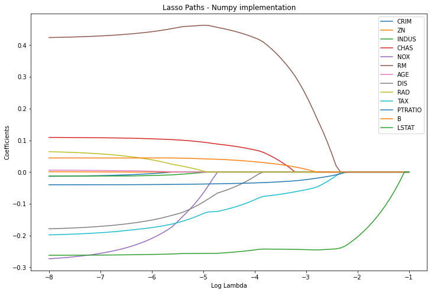

```python
p, _ = myout.shape
plt.figure(figsize = (12,8))

for i in range(p-1):
    plt.plot(log_lam_seq, myout[i+1, :], label = var_names[i])

plt.xlabel('Log Lambda')
plt.ylabel('Coefficients')
plt.title('Lasso Paths - Numpy implementation')
plt.legend()
plt.axis('tight')
```

```python
%cd ~/Desktop
lasso_coef = np.genfromtxt("Coding2_lasso_coefs.csv", delimiter=',',
                           skip_header=1)
lasso_coef.shape
```

```
/Users/sergiobecerra/Desktop
```

```
(14, 80)
```

The error is small and less than 0.005:

```python
abs(myout - lasso_coef).max()
```

```
0.004645317416184014
```

## Part 2

PLEASE IGNORE EVERYTHING BELOW HERE I WILL BE SUBMITTING PART 2 IN R AND WILL LINK THE HTML PAGE

```python
from glmnet import glmnet; from glmnetPlot import glmnetPlot
from glmnetPrint import glmnetPrint; from glmnetCoef import glmnetCoef; from glmnetPredict import glmnetPredict
from cvglmnet import cvglmnet; from cvglmnetCoef import cvglmnetCoef
from cvglmnetPlot import cvglmnetPlot; from cvglmnetPredict import cvglmnetPredict
from sklearn.preprocessing import StandardScaler
```

```python
%cd ~/Desktop
bos2=np.genfromtxt("BostonData2.csv", delimiter=',', skip_header=1)
bos3=np.genfromtxt("BostonData3.csv", delimiter=',', skip_header=1)
myData=bos2[:,1:93]
X=myData[:,1:92]
y=myData[:,0]
y=y.reshape(X.shape[0],1)
X.shape
np.random.seed(5933)
```

```
/Users/sergiobecerra/Desktop
```

Here, the 50 datasets are created. It is a randomized list from 0 - n (506). For training the first ntrain id's of each row will be used for training and the last ntest for testing.

```python
T = 50
n = len(y)
ntest = round(n * 0.25)  # test set size
ntrain = n - ntest  # training set size
data_id = np.zeros((n, T))
for t in range(T):
  data_id[:, t] = np.array(np.random.choice(range(n), n,replace=False))

data_id=data_id.astype(int)
```

### Seven Procedures

```
0.01920641878283905
0.03507611013491697
```

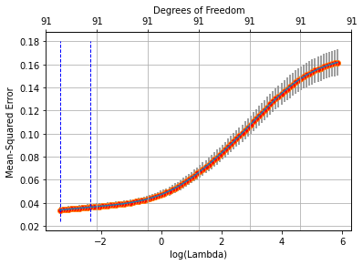

```python
Xtrain=X[data_id[0:ntrain,0],]
Ytrain=y[data_id[0:ntrain,0],]
Xtest=X[data_id[ntrain:,0],]
Ytest=y[data_id[ntrain:,0],]

fullModel = lm.LinearRegression()
fullModel.fit(Xtrain, Ytrain)
Ypred=fullModel.predict(Xtest)
sse=(Ytest-Ypred)
sse=np.mean(sse*sse)
print(sse)
fit=cvglmnet(x=Xtrain,y=Ytrain,alpha=0)
best_lam=fit['lambda_min']
Ypred=cvglmnetPredict(fit,newx=Xtest)
sse=(Ytest-Ypred)
sse=np.mean(sse*sse)
print(sse)
cvglmnetPlot(fit)
```

Unfortunately I was not able to set a lambda sequence with glmnet_py... My only workaround was to force set the minimum lamda value (lambda_min is an input argument). Similar to setting a sequence, this allowed to explore the lambda domain and find the "U-Shape" at a much smaller lambda values.

```
[[3.05902321e-07]]
```

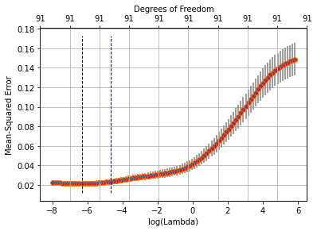

```python
lam_seq=np.exp(np.linspace(-4,1,100))
lmin=np.ones((1,1))
lmin=lmin/np.exp(15)
print(lmin)
fit=cvglmnet(x=Xtrain,y=Ytrain,alpha=0,lambda_min=lmin)

cvglmnetPlot(fit)
```